# ex_2b_en

### *Foreword -- BillyLjm*

Hey, these are my submissions for the **IBM Quantum Challenge, Fall 2020**  
All my solutions are publicly available in my GitHub repo at /BillyLjm/IBMQuantumChallenge2020  
This notebook starts off introducing the problem, but you can jump directly to the solution at Learning Exercise II-B

I ended up implementing multiple approaches which solved this exercise:

1. Tailored |switches>
2. |address>|switches> Search
3. Nested Grover's Algorithm
4. Sequential Grover's Algorithm (Submitted)

```python
from IPython.display import Image, display
Image("ryoko.png", width="70")
```

[output not shown]

# Message from Dr. Ryoko

"Hi! I hope you now understand how the Lights Out puzzle works.  
The floor of the room I must cross has 3 x 3 tiles. Each tile is made of a single qubit.  
Some of these qubits fluctuate between the ground state and the excited state.  
I have been observing their behavior and noticed that there is a pattern - the floor can only be in either one of the four patterns as shown in each of the examples below.  
Due to decoherence, there is not enough time to play around with the switches.  
You need to find out which board can be cleared with three switch operations. Good luck!"

# Week2-B: Four-Lights Out

In this problem, we are dealing with multiple binary data at the same time. We have to determine if each of the given four Lights Out boards are solvable under the given constraints, so let's devise a quantum circuit to solve them all at the same time.

As an example, let's consider how to find a board that can be cleared with just a single switch operation from the 4 boards given below. The initial state of the 4 boards is given in the following two-dimensional array, where "0" and "1" represent "off" and "on" respectively similar to the previous learning problem:

lightsout4_ex=[[Board 0],[Board 1],[Board 2],[Board 3]]

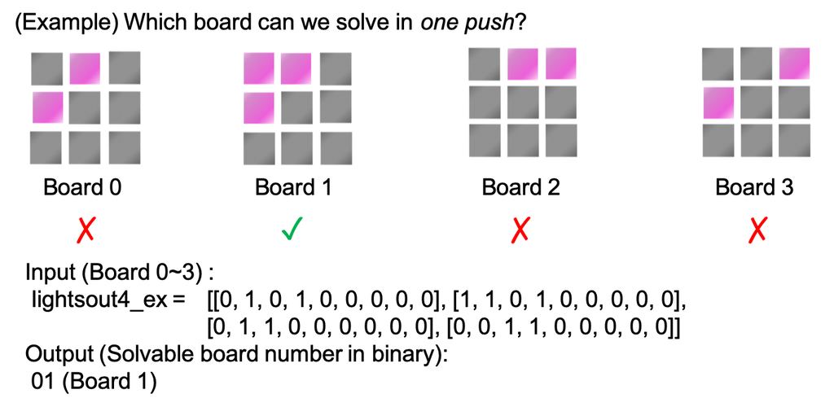

```python
from IPython.display import Image, display
Image('4lightsout_ex.png')
```

## Answer Strategy

If only one board is given, this is a decision problem. Using the algorithm from the first Lights Out puzzle (2A), you can solve this problem by counting the "1"s in the output.

If we are given multiple boards, there will be several approaches.

1. Iterate the same "one board algorithm" for each board.
2. Hold information for multiple boards at the same time and solve the problems in a single run (execute the algorithm once).
- For the rest of this document, we discuss how to use the latter approach to solve this type of problem.

First, how do we keep data for all the boards at the same time?

1. Naive data structures: 9 Qubits/board * 4 boards > 32 qubits (Upper limit of ibm_qasm_simulator).
2. Prepare the superposition state: $\vert Board 0\rangle + \vert Board 1\rangle + \vert Board 2\rangle + \vert Board 3\rangle$.
   - The circuit configuration used for state generation is non-trivial.
3. *qRAM* is known as one solution.
   - **Pros**: Intuitive implementation.
   - **Cons**: Computationally expensive.

Of course you can devise and adopt other smart ways to do this.

Here, we will focus on *qRAM* and describe its configuration and implementation.

```python
from qiskit import QuantumRegister, ClassicalRegister, QuantumCircuit
from qiskit import Aer, execute

from qiskit.transpiler import PassManager
from qiskit.transpiler.passes import Unroller, Optimize1qGatesDecomposition
pass_manager = PassManager(Unroller(['u', 'cx']))

from numpy import pi
from math import ceil
```

## qRAM: Quantum Random Access Memory

In classical computers, RAM (Random Access Memory) is a type of volatile memory that has memory addresses $j$ and stores binary data corresponding to each address $D_j$.

In the case of [qRAM](https://arxiv.org/abs/0708.1879) in a quantum computer, **address qubits $a$** have the $N$-addresses as superposition and the corresponding binary data is stored in **data qubits $d$** as a state vector. $$ \sum_{j}\frac{1}{\sqrt{N}}\vert j \rangle_{a}\vert 0 \rangle_{d}\xrightarrow{qRAM}\sum_{j}\frac{1}{\sqrt{N}}\vert j \rangle_{a}\vert D_{j} \rangle_{d} $$　　 We call the right-hand side state "qRAM" and the corresponding gate operation "qRAM operation".

Although qRAM operation requires $\mathcal{O}(N\log N)$ gates, it can be used to create superposition states of binary data intuitively.

qRAM has previously been applied to various quantum machine learning algorithms such as the HHL algorithm. For this problem, let's apply qRAM to Grover's algorithm.

## Example: Find the data from qRAM

Prepare a qRAM of $n$-addresses in which the numbers $k_0, k_1, .. , k_{n-1}$ are stored in this order.  
Find the address in which the number $m$ is stored using Grover's algorithm.

- $n = 4$
- $k = [1,2,5,7]$
- $m = 7$

### qRAM operation.

Here we show a circuit example of qRAM.

```
{'00001': 2008, '10101': 2039, '11111': 1964, '01010': 1989}
```

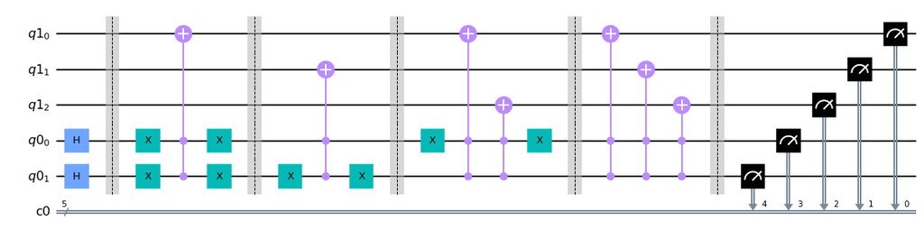

```python
address = QuantumRegister(2)
data = QuantumRegister(3)
c = ClassicalRegister(5)
qc = QuantumCircuit(address,data,c)

# address preparation
qc.h([address[0],address[1]])
qc.barrier()
# address 0 -> data = 1
qc.x([address[0],address[1]])
qc.ccx(address[0],address[1],data[2])
qc.x([address[0],address[1]])
qc.barrier()
# address 1 -> data = 2
qc.x(address[0])
qc.ccx(address[0],address[1],data[1])
qc.x(address[0])
qc.barrier()
# address 2 -> data = 5
qc.x(address[1])
qc.ccx(address[0],address[1],data[2])
qc.ccx(address[0],address[1],data[0])
qc.x(address[1])
qc.barrier()
# address 3 -> data = 7
qc.ccx(address[0],address[1],data[2])
qc.ccx(address[0],address[1],data[1])
qc.ccx(address[0],address[1],data[0])
qc.barrier()

#Check the qRAM　status
qc.measure(address[0:2], c[0:2])
qc.measure(data[0:3], c[2:5])

# Reverse the output string.
qc = qc.reverse_bits()

backend = Aer.get_backend('qasm_simulator')
job = execute(qc, backend=backend, shots=8000, seed_simulator=12345, backend_options={"fusion_enable":True})
result = job.result()
count =result.get_counts()
print(count)

qc.draw(output='mpl')
```

### qRAM Data Search

To perform Grover's algorithm, we invert the sign of the **address qubit** containing $m$. We also need to initialize the **data qubit** by another qRAM operation before the Diffusion operation,

\begin{align*} \vert j \rangle_{a}\vert D_{j} \rangle_{d} \vert - \rangle_{f} \xrightarrow{oracle} \left \{ \begin{array}{l} -\vert j \rangle_{a}\vert D_{j} \rangle_{d} \vert - \rangle_{f}, D_{j} = m\\ \vert j \rangle_{a}\vert D_{j} \rangle_{d} \vert - \rangle_{f}, D_{j} \neq m \end{array} \right. \xrightarrow{qRAM} \left \{ \begin{array}{l} -\vert j \rangle_{a}\vert 0 \rangle_{d}\vert - \rangle_{f}, D_{j} = m \\ \vert j \rangle_{a}\vert 0 \rangle_{d}\vert - \rangle_{f}, D_{j}\neq m \end{array} \right. \end{align*}

where $f$ denotes the flag qubit.

In this case, we can configure an oracle operation using the [C3X gate](https://qiskit.org/documentation/stubs/qiskit.circuit.library.C3XGate.html#qiskit.circuit.library.C3XGate) .

Here, we show the whole circuit for our qRAM example.

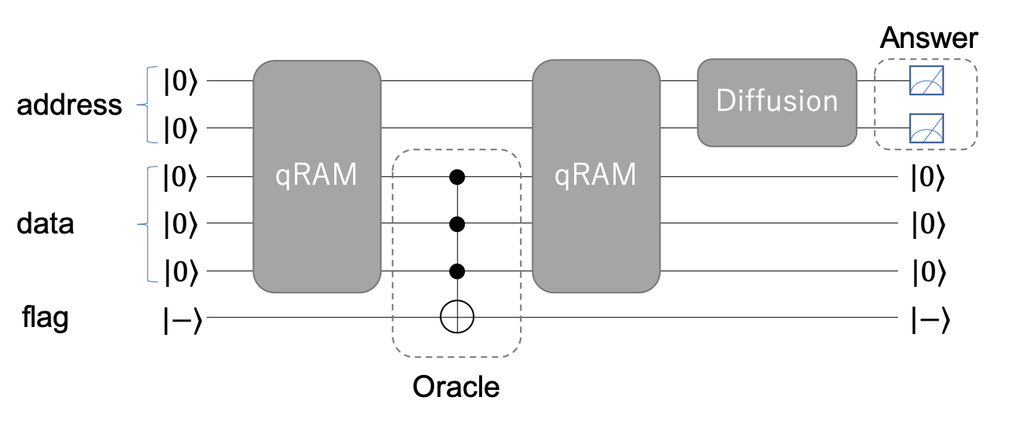

```python
Image('circuit_ex.png')
```

### Considerations for qRAM implementation

In the above description we have introduced a naive *qRAM operation* circuit. Depending on the data structure, we can simplify the circuit by using **gate synthesis** (equivalence transformation) techniques. Also, some simplified gates, e.g. [RCCX](https://qiskit.org/documentation/stubs/qiskit.circuit.library.RCCXGate.html#qiskit.circuit.library.RCCXGate), may help improve your *CNOT*-saving implementation.

An example of gate synthesis is shown below.

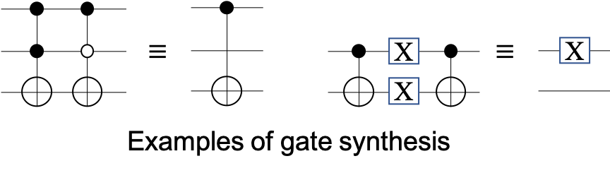

```python
Image('gatesynthesis_ex.png')
```

## Learning Exercise II-B

Let's solve a 4-Lights Out problem with qRAM.

When the initial board state lightsout4=[[Board 0],[Board 1],[Board 2],[Board 3]] is described by the following data, determine the *binary* number of the solvable boards in $3$ switch operations. (ex. Board 0 → 00, 1 → 01, 2 → 10, 3 → 11)

Answer by creating a quantum circuit to solve the puzzle shown in the figure below. In the quantum circuit to be submitted, measure only the `solution` (2bit) that solves the puzzle.

To submit your solution, create a function which takes "lightsout4" as an input and returns `QuantumCircuit`. You can choose a function name you like. Make sure it works even if you input another dataset to "lightsout4".

**In addition, please implement the quantum circuit within 28 qubits.**

Please note that you can get the answer with the same endian as the one used in the description. You can also use the following function.

```
qc = qc.reverse_bits()
```

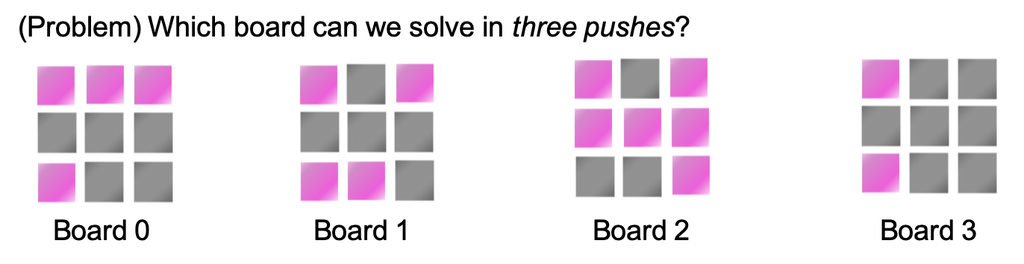

```python
Image('4lightsout_pr.png')
```

```python
lightsout4=[[1, 1, 1, 0, 0, 0, 1, 0, 0],[1, 0, 1, 0, 0, 0, 1, 1, 0],[1, 0, 1, 1, 1, 1, 0, 0, 1],[1, 0, 0, 0, 0, 0, 1, 0, 0]]

# for drawing (2x2 version)
lightsout4_2x2=[[1,1,1,1], [1,0,0,0], [1,1,1,1], [1,1,1,1]]
```

### Hints

- Change the oracle of qRAM data search to an appropriate one.
- Data storing/writing in *QRAM operation* can be performed in any order. We can reduce the number of gates by taking into account the *hamming distance* of the address and input data.

```
OrderedDict([('u', 125), ('cx', 54)])
```

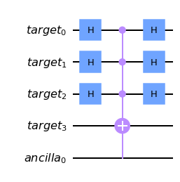

```python
def diffuse(nbits, start='+'):
    """Grover diffusion circuit

    Parameters:
        nbits (int): number of qubits to diffuse
        start (bool): target register intial state. '0' for |0>|0>... (speed: 1 > - > 0 > +)

    Returns:
        QuantumCircuit for (nbits) target qubits, and (nbits-3) ancilla qubits
    """
    # declare quantum circuit
    targets = QuantumRegister(nbits, 'target')
    ancillae = QuantumRegister(nbits-3, 'ancilla') if nbits > 3 else None
    diffuse = QuantumCircuit(targets, name="Diffuse") if ancillae == None \
        else QuantumCircuit(targets, ancillae, name="Diffuse")

    # transfrom state to |11...1->, phase flip, and reverse tranformation
    if nbits == 1:
        qc.z(targets)
    elif start == '1':
        diffuse.h(targets[-1])
        diffuse.mcx(targets[:-1], targets[-1], ancillae, mode='v-chain')
        diffuse.h(targets[-1])
    elif start == '-':
        diffuse.h(targets[:-1])
        diffuse.mcx(targets[:-1], targets[-1], ancillae, mode='v-chain')
        diffuse.h(targets[:-1])
    elif start == '0':
        diffuse.u(pi/2, pi, pi, targets[-1]) # HX gate
        diffuse.x(targets[:-1])
        diffuse.mcx(targets[:-1], targets[-1], ancillae, mode='v-chain')
        diffuse.x(targets[:-1])
        diffuse.u(pi/2, 0, 0, targets[-1]) # XH gate
    elif start == '+':
        diffuse.u(pi/2, 0, 0, targets[:-1]) # XH gate
        diffuse.z(targets[-1])
        diffuse.mcx(targets[:-1], targets[-1], ancillae, mode='v-chain')
        diffuse.z(targets[-1])
        diffuse.u(pi/2, pi, pi, targets[:-1]) # HX gate

    return diffuse

# calculate score contribution
qc = diffuse(11, start="-")
print(pass_manager.run(qc).count_ops())

# draw circuit
qc = diffuse(4, start="-")
qc.draw(output="mpl")
```

```
OrderedDict([('cx', 33)])
```

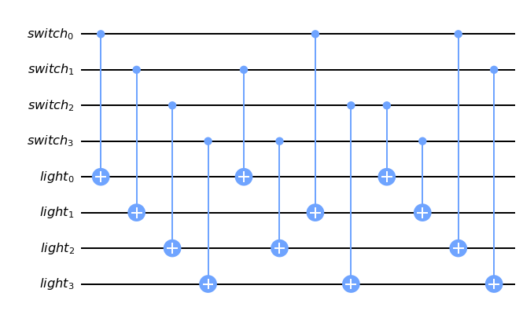

```python
def lightsout(nrows, ncols):
    """Apply lights-out solution
    from a quantum register of switches to flip
    onto a quantum register of lights

    Parameters:
        nrows (int): number of rows in lights-out board
        ncols (int): number of columns in lights-out board

    Returns:
        QuantumCircuit for (nrows * ncols) switches qubits,
        and (nrows * ncols) lights qubits
    """
    # declare quantum circuit
    nbits = nrows * ncols
    switches = QuantumRegister(nbits, 'switch')
    lights = QuantumRegister(nbits, 'light')
    lightsout = QuantumCircuit(switches, lights, name="lights out")

    # applies switches to lights
    for i in range(nbits): # flip current tile
        lightsout.cx(switches[i], lights[i])
    for i in range(nbits): # flip left tile
        lightsout.cx(switches[i], lights[i-1]) if i%ncols != 0 else None
    for i in range(nbits): # flip right tile
        lightsout.cx(switches[i], lights[i+1]) if (i%ncols != ncols-1 and i != nbits-1) else None
    for i in range(nbits): # flip top tile
        lightsout.cx(switches[i], lights[i-ncols]) if i >= ncols else None
    for i in range(nbits): # flip bottom tile
        lightsout.cx(switches[i], lights[i+ncols]) if i < nbits-ncols else None

    return lightsout

# calculate score contribution
qc = lightsout(3, 3)
print(pass_manager.run(qc).count_ops())

# draw circuit
qc = lightsout(2, 2)
qc.draw(output="mpl")
```

```
OrderedDict([('u', 53), ('cx', 32)])
```

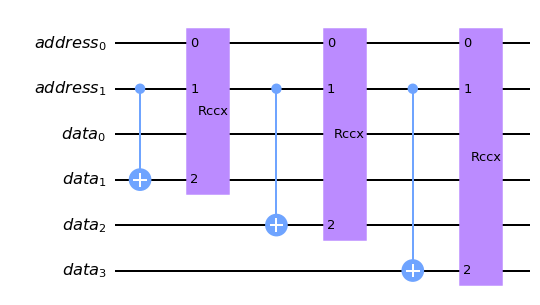

```python
def qram4(data, reverse=True):
    """ QRAM loading for up to 4 addresses
    allows classical data to be loaded into a quantum register, via a quantum address
    if the address is |00>, data[0] will be loaded into the quantum data register

    Parameters:
        data (2D list): list of data to be loaded, in addressed order
        reverse (bool): True to flip 0 <-> 1 from data to quantum register

    Returns:
        QuantumCircuit for 2 address qubits, and len(data) data qubits
    """
    # decalre variables
    naddr = len(data) # number of data addresses
    nbits = len(data[0]) # number of data bits
    assert(naddr <= 4)

    # declare quantum circuit
    qaddr = QuantumRegister(2, 'address') # address register
    qdata = QuantumRegister(nbits, 'data') # data register
    qram = QuantumCircuit(qaddr, qdata, name='QRAM')

    for i in range(nbits):
        # load 00 data
        if reverse:
            qram.x(qdata[i]) if data[0][i] == 0 else None
        else:
            qram.x(qdata[i]) if data[0][i] == 1 else None
        # load 01 data (least significant bit is qaddr[-1])
        if naddr > 1:
            qram.cx(qaddr[1], qdata[i]) if data[0][i] != data[1][i] else None
        # load 10 data (most significant bit is qaddr[0])
        if naddr > 2:
            qram.cx(qaddr[0], qdata[i]) if data[0][i] != data[2][i] else None
        # load 11 data
        if naddr > 3:
            qram.rccx(qaddr[0], qaddr[1], qdata[i]) if data[0][i] ^ data[1][i] ^ \
                data[2][i] != data[3][i] else None
    return qram

# calculate score contribution
qc = qram4(lightsout4, reverse=True)
print(pass_manager.run(qc).count_ops())

# draw circuit
qc = qram4(lightsout4_2x2, reverse=True)
qc.draw(output="mpl")
```

```
OrderedDict([('u', 352), ('cx', 177)])
```

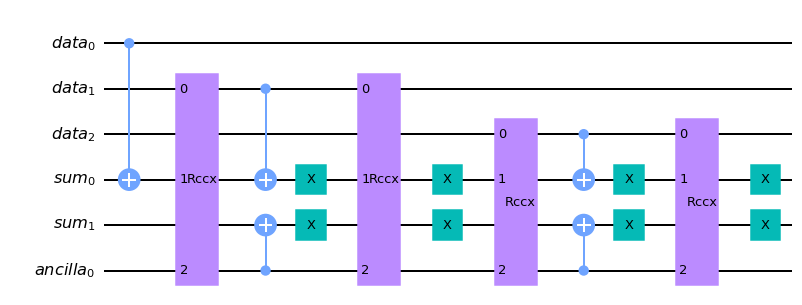

```python
def adder(nbits):
    """ Counts the number of 1's in a register
    into another sum register in binary form

    Parameters:
        nbits (int): number of input bits to add

    Returns:
        QuantumCircuit for (nbits) data qubits, (nsum) sum qubits,
        and (nsum-1) ancilla qubits; where nsum = len(bin(nbits))-2
    """
    # declare variables
    nsum = len(bin(nbits)[2:])

    # declare quantum circuit
    data = QuantumRegister(nbits, 'data')
    summ = QuantumRegister(nsum, 'sum')
    ancillae = QuantumRegister(nsum-1, 'ancilla') if nsum > 1 else None
    adder = QuantumCircuit(data, summ, name='adder') if ancillae == None else \
         QuantumCircuit(data, summ, ancillae, name='adder')

    # add 1st bit
    adder.cx(data[0], summ[0])
    # add subsequent qubits
    for i in range(1, nbits):
        # mark where carry-over occurs w/ ancillae
        adder.rccx(data[i], summ[0], ancillae[0])
        for j in range(1, nsum-1):
            adder.rccx(summ[j], ancillae[j-1], ancillae[j])
        # execute carry-over onto sum register
        for j in range(nsum-1):
            adder.cx(ancillae[j], summ[j+1])
        adder.cx(data[i], summ[0])
        # reset ancillae to |00...0>
        adder.x(summ)
        for j in reversed(range(1,nsum-1)):
            adder.rccx(summ[j], ancillae[j-1], ancillae[j])
        adder.rccx(data[i], summ[0], ancillae[0])
        adder.x(summ)

    return adder

# calculate score contribution
qc = adder(9)
print(pass_manager.run(qc).count_ops())

# draw circuit
qc = adder(3)
qc.draw(output="mpl")
```

```
OrderedDict([('cx', 114), ('u', 93)])
```

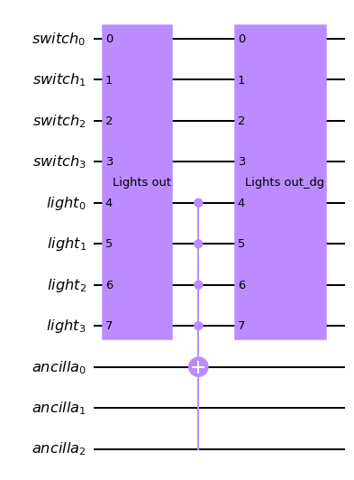

```python
def oracle_lightsout(nrows, ncols, off_val=0, ancillae_init=False):
    """ Grover oracle to check for solution to lights-out puzzle

    Parameters:
        nrows (int): number of rows in lights-out grid
        ncols (int): number of columns in lights-out grid
        off_val (0 or 1): value representing an unlit light (1 is faster)
        ancillae_init (bool): True if ancillae initalised to |-0...0>,
                              False if ancillae intiliased to |00..0>

    Returns:
        QuantumCircuit for (nrows * ncols) switches qubits, (nrows * ncols)
        lights register, and max(nrows * ncols - 1, 1) ancilla qubits
    """
    # declare variables
    nbits = nrows * ncols

    # declare subcircuits
    lo = lightsout(nrows, ncols).to_instruction()

    # declare quantum circit
    switches = QuantumRegister(nbits, 'switch')
    lights = QuantumRegister(nbits, 'light')
    ancillae = QuantumRegister(max(nbits-1, 1), 'ancilla')
    oracle = QuantumCircuit(switches, lights, ancillae, name="oracle_lights")

    # apply switches to lights
    oracle.x(lights) if off_val == 0 else None
    oracle.append(lo, [*switches, *lights])

    # phase flip
    oracle.u(pi/2, pi, pi, ancillae[0]) if not ancillae_init else None # HX gate
    oracle.mcx(lights, ancillae[0], ancillae[1:], mode='v-chain')
    oracle.u(pi/2, 0, 0, ancillae[0]) if not ancillae_init else None # XH gate

    # uncompute lights & ancilla
    oracle.append(lo.inverse(), [*switches, *lights])
    oracle.x(lights) if off_val == 0 else None

    return oracle

# calculate score contribution
qc = oracle_lightsout(3, 3, off_val=1, ancillae_init=True)
print(pass_manager.run(qc).count_ops())

# draw circuit
qc = oracle_lightsout(2, 2, off_val=1, ancillae_init=True)
qc.draw(output="mpl")
```

### 1st Attempt: Tailored |Switches>

My first attempt was to create an uneven superposition of <=3 flips in the switches register.  
The standard Grover's algorithm can then used to search through the `|address>|switches w/ <= 3 flips>`

This method works for the given problem, returning the correct `|address>` .  
However, it has a higher cost than my 3rd attempt; despite having a less conceptually convoluted loop.

```
OrderedDict([('u', 1109), ('cx', 606)])
```

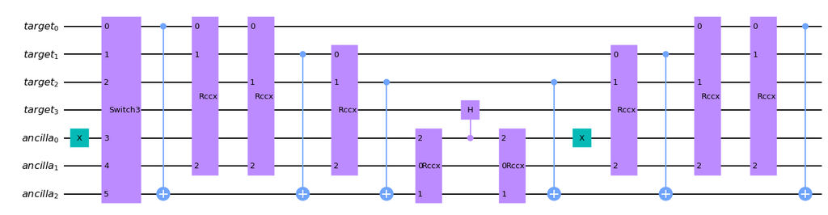

```python
def switch3(nbits, ancillae_init=False):
    """ Creates an uneven superposition of up to three 1's
    in a quantum register initalised to |00...>

    Parameters:
        n (int): number of qubits in register
        ancillae_init (bool): True if ancillae initialised in |100>,
                              False if ancillae initialised in |000>

    Returns:
        QuantumCircuit for a nbits target qubits, and 3 ancilla qubits
    """
    # declare qubits
    targets = QuantumRegister(nbits, 'target')
    ancillae = QuantumRegister(3, 'ancilla')
    sw3 = QuantumCircuit(targets, ancillae, name='switch3')

    # base case
    if nbits <= 3:
        sw3.h(targets)
    else:
        # recursively ensure preceeding qubits has less than three 1's
        sw3.x(ancillae[0]) if not ancillae_init else None
        sw3.append(switch3(nbits-1, ancillae_init=True).to_instruction(), \
                       [*targets[:-1], *ancillae])

        # count 1's in preceeding qubits (<= 3)
        for i in range(nbits-1):
            sw3.cx(targets[i], ancillae[2])
            for j in range(i+1, nbits-1):
                sw3.rccx(targets[i], targets[j], ancillae[1])

        # CCH next qubit if precceeding bits has less than three 1s
        sw3.rccx(ancillae[1], ancillae[2], ancillae[0])
        sw3.ch(ancillae[0], targets[-1])
        sw3.rccx(ancillae[1], ancillae[2], ancillae[0])

        # Uncompute count
        for i in reversed(range(nbits-1)):
            for j in reversed(range(i+1, nbits-1)):
                sw3.rccx(targets[i], targets[j], ancillae[1])
            sw3.cx(targets[i], ancillae[2])
        sw3.x(ancillae[0]) if not ancillae_init else None

    return sw3

# calculate score contribution
qc = switch3(9, ancillae_init=False)
print(pass_manager.run(qc).count_ops())

# draw circuit
qc = switch3(4, ancillae_init=False)
qc.draw(output="mpl", fold=50)
```

```
OrderedDict([('cx', 1444), ('u', 1338), ('measure', 2)])
```

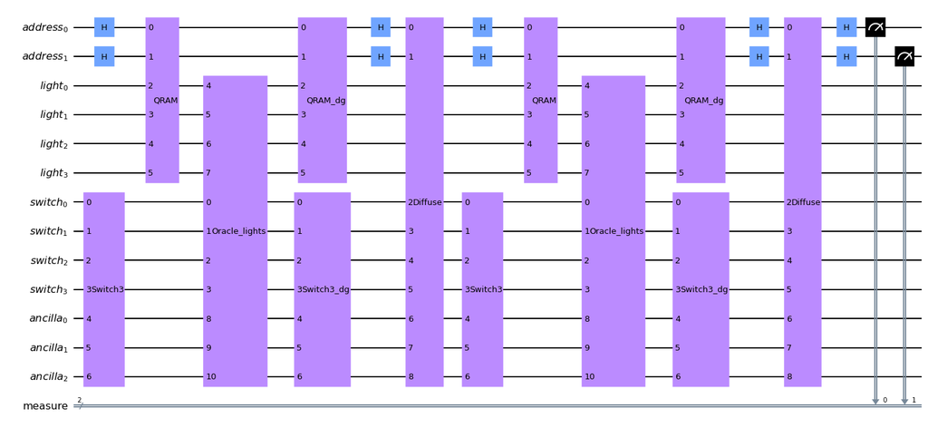

```python
def week2b_ans_alt(data, nrows=3, ncols=3, niter=1, grading=True):
    """ Grover search algorithm to find which lights-out puzzle
    can be solved by less than 3 switch flips

    Parameters:
        data (2D list): list of lights-out puzzles (up to 4); each puzzle
                        has a list indicating which lights are on/off
        nrows (int): number of rows in lights-out board
        ncols (int): number of columns in lights-out board
        niter (int): number of iterations of Grover search
        grading (bool): True to reverse-bits & unroll for grading

    Returns:
        QuantumCircuit for 2 address qubits, (nrows * ncols) lights register,
        (nrows * ncols) switches register, (nrows * ncols - 2) + 3 auxiliary
        |0> qubits, and (nrows * ncols) classical measurement register
    """
    # declare variables
    nbits = nrows * ncols
    assert(len(data[0]) == nbits and len(data) <= 4)

    # declare subcircuits
    sw = switch3(nbits, ancillae_init=False).to_instruction()
    qrm = qram4(data, reverse=True).to_instruction()
    ora = oracle_lightsout(nrows, ncols, 1, False).to_instruction()
    diff = diffuse(nbits+2, start="0").to_instruction()

    # declare quantum circuit
    addresses = QuantumRegister(2, 'address') # address of lights
    lights = QuantumRegister(nbits, 'light') # lights-out boards
    switches = QuantumRegister(nbits, 'switch') # to switch lights
    ancillae = QuantumRegister(max(nbits-1, 2), 'ancilla') # general ancilla
    measure = ClassicalRegister(2, 'measure') # to measure address into
    ex2b = QuantumCircuit(addresses, lights, switches, ancillae, measure)

    # initialise qubits
    ex2b.h(addresses)
    ex2b.append(sw, [*switches, *ancillae[:3]])

    # Grover iteration
    for _ in range(niter):
        # oracle
        ex2b.append(qrm, [*addresses, *lights])
        ex2b.append(ora, [*switches, *lights, *ancillae[:max(nbits-1, 1)]])
        ex2b.append(qrm.inverse(), [*addresses, *lights])
        # transform to |00...0> for diffusion
        ex2b.h(addresses)
        ex2b.append(sw.inverse(), [*switches, *ancillae[:3]])
        # diffusion
        ex2b.append(diff, [*addresses, *switches]) if nbits <= 1 else \
            ex2b.append(diff, [*addresses, *switches, *ancillae[:nbits-1]]) # diffuse
        # uncompute transform
        ex2b.append(sw, [*switches, *ancillae[:3]]) if _ != niter-1 else None
        ex2b.h(addresses)

    # output
    ex2b.measure(addresses, measure)
    if grading: # optimisation
        ex2b = ex2b.reverse_bits()
        ex2b = PassManager(Unroller(['u', 'cx'])).run(ex2b)
        ex2b = PassManager(Optimize1qGatesDecomposition(['u', 'cx'])).run(ex2b)
    return ex2b

# calculate score contribution
qc = week2b_ans_alt(lightsout4, 3, 3, niter=1, grading=True)
print(pass_manager.run(qc).count_ops())

# draw circuit
qc = week2b_ans_alt(lightsout4_2x2, 2, 2, niter=2, grading=False)
qc.draw(output="mpl", fold=50)
```

This circuit is really large & simulating it take really long, especially for large lights-out boards.  
Thus, I won't run for multiple iterations on 3x3 boards, and instead run it on 2x2 boards here.

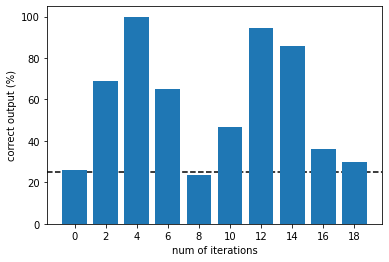

```python
import matplotlib.pyplot as plt
%matplotlib inline

backend = Aer.get_backend('qasm_simulator')
niter = tuple(range(0, 19, 2))
num_correct = []
shots = 10000

for i in niter:
    qc = week2b_ans_alt(lightsout4_2x2, 2, 2, niter=i)
    job = execute(qc, backend, shots=shots)
    answer = job.result().get_counts()['01']
    num_correct.append(answer / shots * 100)

plt.bar(niter, num_correct, width=1.6)
plt.axhline(y=25, linestyle="--", color='k', zorder=-1)
plt.xticks(niter)
plt.xlabel('num of iterations')
plt.ylabel('correct output (%)')
plt.show()
```

And to demonstrate that it works for this specific problem set,

```python
# Submission code
from qc_grader import prepare_ex2b, grade_ex2b, submit_ex2b

# Execute your circuit with following prepare_ex2b() function.
# The prepare_ex2b() function works like the execute() function with only QuantumCircuit as an argument.
job  =  prepare_ex2b(week2b_ans_alt)
counts = job.result().get_counts()[0]

# The bit string with the highest number of observations is treated as the solution
counts_desc = sorted(counts.items(), key = lambda x: x[1], reverse=True)
print(counts_desc[:5])
```

```
Running week2b_ans_alt...
Computing cost...
Starting experiments. Please wait...
You may monitor the job (id: 5fc21f566fe772001ae2aeac) status and proceed to grading when it successfully completes.
[('01', 2355), ('10', 1922), ('00', 1887), ('11', 1836)]
```

### 2nd Attempt: |address>|switches> search

An alternate approach is to search through the combined `|address>|switches>` states.  
This uses single oracle which checks if the switches is simultaneously a solution and has <=3 flips

This method identifies the correct `|address>|switches>`, but does not seem to give the correct `|address>`  
The reason is because the correct `|address>` also has many wrong `|switches>` which gets supressed.  
Thus, the amplitude amplification cancels out when combining (i.e. parital tracing) all these `|switches>`.

However, this method can still work for smaller search spaces and/or larger number of iterations,  
where the algorithm is able to amplify the correct `|address>|switches>` enough to dominate the results

```
OrderedDict([('u', 1910), ('cx', 1092)])
```

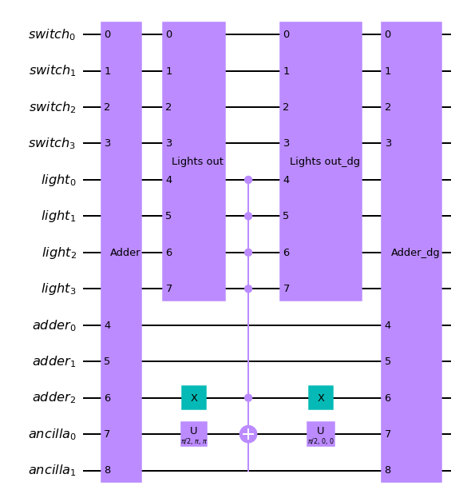

```python
def oracle_2b(nrows, ncols, off_val=0):
    """ Grover oracle for exercise 2b
    Checks if (1) given switches turns off all lights
              (2) number of switch flips is <= 3
    this curently uses mcx(mode='recursion') to reduce number of qubits

    Parameters:
        nrows (int): number of rows in lights-out board
        ncols (int): number of columns in lights-out board
        off_val (0 or 1): value representing an unlit light (1 is faster)

    Returns:
        QuantumCircuit for (nrows * ncols) switches qubits, (nrows * ncols)
        lights register, (nadder) adder regsiter, and max(nadder-1, 2) ancilla
        qubits; where nbits = (nrows * ncols) and nadder = len(bin(nbits))-2
    """
    # declare variables
    nbits = nrows * ncols # board bits
    nadder = len(bin(nbits)) - 2 # adder result bits

    # declare subcircuits
    lo = lightsout(nrows, ncols).to_instruction()
    add = adder(nbits).to_instruction()

    # declare quantum circuit
    switches = QuantumRegister(nbits, 'switch')
    lights = QuantumRegister(nbits, 'light')
    adders = QuantumRegister(nadder, 'adder')
    ancillae = QuantumRegister(max(nadder-1, 2), 'ancilla')
    oracle = QuantumCircuit(switches, lights, adders, ancillae, name="oracle_2b")

    # apply switches to lights & count number of switches
    oracle.append(add, [*switches, *adders, *ancillae[:nadder-1]])
    oracle.x(lights) if off_val == 0 else None
    oracle.append(lo, [*switches, *lights])

    # phase flip
    oracle.x(adders[2:])
    oracle.u(pi/2, pi, pi, ancillae[0]) # HX gate
    oracle.mcx([*lights, *adders[2:]], ancillae[0], ancillae[1], mode='recursion')
    oracle.u(pi/2, 0, 0, ancillae[0]) # XH gate
    oracle.x(adders[2:]) if nadder > 2 else None

    # uncompute lights
    oracle.append(lo.inverse(), [*switches, *lights])
    oracle.x(lights) if off_val == 0 else None
    oracle.append(add.inverse(), [*switches, *adders, *ancillae[:nadder-1]])

    return oracle

# calculate score contribution
qc = oracle_2b(3, 3, off_val=1)
print(pass_manager.run(qc).count_ops())

# draw circuit
qc = oracle_2b(2, 2, off_val=1)
qc.draw(output="mpl")
```

```
OrderedDict([('u', 1346), ('cx', 1210), ('measure', 11)])
```

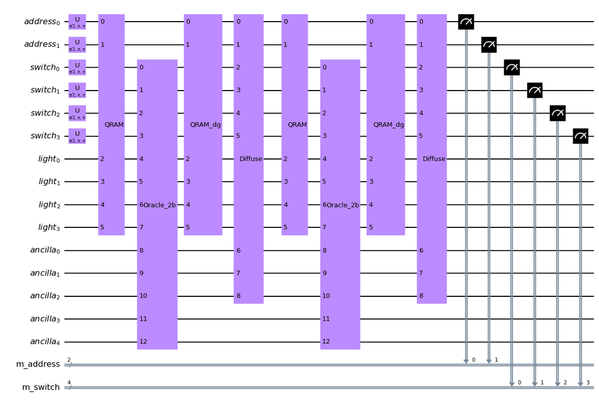

```python
def week2b_ans_alt2(data, nrows=3, ncols=3, niter=1, grading=True):
    """ Grover search algorithm to find which lights-out puzzle
    can be solved by less than 3 switch flips

    Parameters:
        data (2D list): list of lights-out puzzles (up to 4); each puzzle
                        has a list indicating which lights are on/off
        nrows (int): number of rows in lights-out board
        ncols (int): number of columns in lights-out board
        niter (int): number of iterations of Grover search
        grading (bool): True to reverse-bits & unroll for grading

    Returns:
        QuantumCircuit for 2 address qubits, (nrows * ncols) lights register,
        (nrows * ncols) switches register, max(nbits-1, 2*nadder-1, nadder + 2)
        auxiliary |0> qubits, and (nrows * ncols) classical measurement register
    """
    # declare variables
    nbits = nrows * ncols
    nadder = len(bin(nbits))-2
    assert(len(data[0]) == nbits and len(data) <= 4)

    # declare subcircuits
    qrm = qram4(data, reverse=True).to_instruction()
    ora = oracle_2b(nrows, ncols, off_val=1).to_instruction()
    diff = diffuse(nbits+2, start="-").to_instruction()

    # declare quantum circit
    addresses = QuantumRegister(2, 'address') # address of boards
    switches = QuantumRegister(nbits, 'switch') # to switch lights
    lights = QuantumRegister(nbits, 'light') # lights-out boards
    ancillae = QuantumRegister(max(nbits-1, 2*nadder-1, nadder+2), 'ancilla')
    meas_addr = ClassicalRegister(2, 'm_address') # to measure address into
    meas_sw = ClassicalRegister(nbits, 'm_switch')
    ex2b = QuantumCircuit(addresses, switches, lights, ancillae, meas_addr, meas_sw)

    # initialise qubits
    ex2b.u(pi/2, pi, pi, addresses) # |->, start='-' in diffuse
    ex2b.u(pi/2, pi, pi, switches)

    # Grover iteration
    for _ in range(niter):
        # oracle
        ex2b.append(qrm, [*addresses, *lights])
        ex2b.append(ora, [*switches, *lights, *ancillae[:max(2*nadder-1, nadder+2)]])
        ex2b.append(qrm.inverse(), [*addresses, *lights])
        # diffusion
        ex2b.append(diff, [*addresses, *switches]) if nbits <= 1 else \
            ex2b.append(diff, [*addresses, *switches, *ancillae[:nbits-1]]) # diffuse

    # output
    ex2b.measure(addresses, meas_addr)
    ex2b.measure(switches, meas_sw)
    if grading: # optimisation
        ex2b = ex2b.reverse_bits()
        ex2b = PassManager(Unroller(['u', 'cx'])).run(ex2b)
        ex2b = PassManager(Optimize1qGatesDecomposition(['u', 'cx'])).run(ex2b)

    return ex2b

# calculate score contribution
qc = week2b_ans_alt2(lightsout4, 3, 3, niter=1, grading=True)
print(pass_manager.run(qc).count_ops())

# draw circuit
qc = week2b_ans_alt2(lightsout4_2x2, 2, 2, niter=2, grading=False)
qc.draw(output="mpl")
```

To show that this method identifies the correct `|address>|switches>`,

```python
qc = week2b_ans_alt2(lightsout4, 3, 3, niter=1)

backend = Aer.get_backend('qasm_simulator')
job = execute(qc, backend, shots=10000)
counts = job.result().get_counts()

counts_desc = sorted(counts.items(), key = lambda x: x[1], reverse=True)
print(counts_desc[:5])
```

```
[('01 001110000', 42), ('01 000100110', 14), ('11 010111010', 13), ('00 011000011', 13), ('00 101111111', 12)]
```

To show that this method also identifies the correct `|address>` for smaller search spaces,  
We apply it on a list of 2x2 lights-out boards

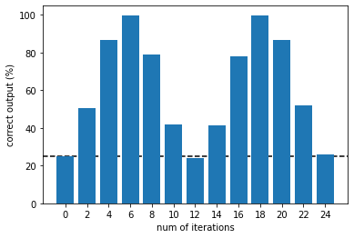

```python
import matplotlib.pyplot as plt
%matplotlib inline

backend = Aer.get_backend('qasm_simulator')
niter = tuple(range(0, 25, 2))
num_correct = [0] * len(niter)
shots = 10000

for i in range(len(niter)):
    qc = week2b_ans_alt2(lightsout4_2x2, 2, 2, niter=niter[i])
    job = execute(qc, backend, shots=shots)
    counts = job.result().get_counts()
    for result in counts: # trace out all the |switches>
        num_correct[i] += counts[result] if result[:2] == '01' else 0
    num_correct[i] = num_correct[i] / shots * 100

plt.bar(niter, num_correct, width=1.6)
plt.axhline(y=25, linestyle="--", color='k', zorder=-1)
plt.xticks(niter)
plt.xlabel('num of iterations')
plt.ylabel('correct output (%)')
plt.show()
```

### 3rd Attempt: Nested Grover's Algorithm

This implementation follows the hints given in `hint_2b.pdf` .  
It uses 2 disntict Grover's algorithm, to implement the following steps:

1. Create superposition of `|addresses x boards> |switches>`
2. 1st Grover algorithm to amplify all lights-out solutions `|addresses x boards x switch solution>`
3. 2nd Grover algorithm to amplify only solution with <= 3 flips `|address x solution w/ <= 3 flip>`

Although this method is the furthest from textbook-Grover, it does seem to have the lowest cost.  
Additionally, it does indeed seem to give the correct answer in the least amount of iterations.

```
OrderedDict([('u', 717), ('cx', 360)])
```

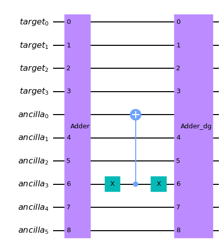

```python
def oracle_lt3(nbits, ancillae_init=False):
    """ Grover oracle to check if target register <= 3 1's

    Parameters:
        nbits (int): number of bits in target regsiter
        ancillae_init (bool): True if ancillae initalised to |-0...0>,
                              False if ancillae intiliased to |00..0>

    Returns:
        QuantumCircuit for (nbits) target resgister, and (2 * nsum)
        ancilla qubits; where nsum = len(bin(nbits))-2
    """
    # declare variables
    assert(nbits > 3)
    nsum = len(bin(nbits))-2

    # declare subcircuits
    add = adder(nbits).to_instruction()

    # declare quantum circit
    target = QuantumRegister(nbits, 'target')
    ancillae = QuantumRegister(2 * nsum, 'ancilla')
    oracle = QuantumCircuit(target, ancillae, name="oracle_lt3")

    # count number of 1's
    oracle.append(add, [*target, *ancillae[1:]])
    oracle.x(ancillae[3:nsum+1])

    # phase flip
    oracle.u(pi/2, pi, pi, ancillae[0]) if not ancillae_init else None # HX gate
    oracle.mcx(ancillae[3:nsum+1], ancillae[0], ancillae[nsum+1:], mode='v-chain')
    oracle.u(pi/2, 0, 0, ancillae[0]) if not ancillae_init else None # XH gate

    # uncompute adder
    oracle.x(ancillae[3:nsum+1])
    oracle.append(add.inverse(), [*target, *ancillae[1:]])

    return oracle

# calculate score contribution
qc = oracle_lt3(9, ancillae_init=True)
print(pass_manager.run(qc).count_ops())

# draw circuit
qc = oracle_lt3(4, ancillae_init=True)
qc.draw(output="mpl")
```

```
OrderedDict([('u', 796), ('cx', 737), ('measure', 2)])
```

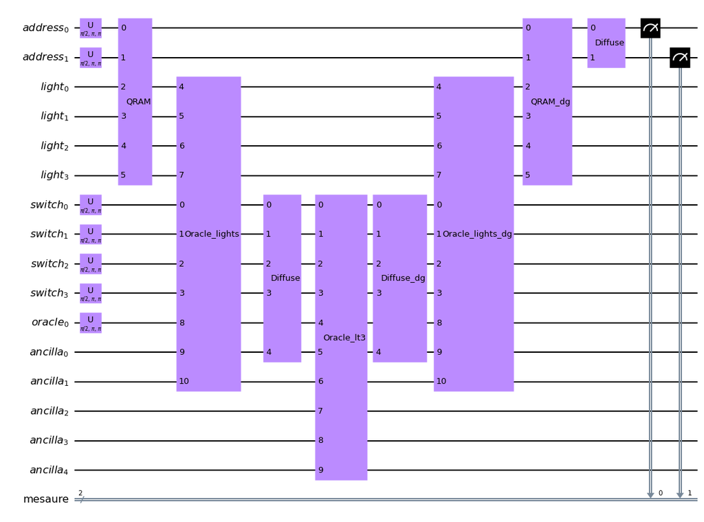

```python
def week2b_ans_alt3(data, nrows=3, ncols=3, niter=[1,1], grading=True):
    """ Grover search algorithm to find which lights-out puzzle
    can be solved by less than 3 switch flips

    Parameters:
        data (2D list): list of lights-out puzzles (up to 4); each puzzle
                        has a list indicating which lights are on/off
        nrows (int): number of rows in lights-out board
        ncols (int): number of columns in lights-out board
        niter (list of int): number of iterations for [0] 1st Grover for
                             address solvable by those switches [1] 2nd
                             Grover for switches w/ <= 3 flips
        grading (bool): True to reverse-bits & unroll for grading

    Returns:
        QuantumCircuit for 2 address qubits, (nrows * ncols) lights register,
        (nrows * ncols) switches register, max(nbits-1, 2*nadder-1, nadder + 2)
        auxiliary |0> qubits, and (nrows * ncols) classical measurement register
    """
    # declare variables
    nbits = nrows * ncols
    nadder = len(bin(nbits))-2
    assert(len(data[0]) == nbits and len(data) <= 4)

    # declare subcircuits
    qrm = qram4(data, reverse=True).to_instruction()
    add = adder(nbits).to_instruction()
    ora_lo = oracle_lightsout(nrows, ncols, off_val=1, ancillae_init=True).to_instruction()
    ora_add = oracle_lt3(nbits, ancillae_init=True)
    diff_sw = diffuse(nbits, start="-").to_instruction()
    diff_addr = diffuse(2, start="-").to_instruction()

    # declare quantum circit
    addresses = QuantumRegister(2, 'address') # address of boards
    lights = QuantumRegister(nbits, 'light') # lights-out boards
    switches = QuantumRegister(nbits, 'switch') # to switch lights
    oracle = QuantumRegister(1, 'oracle') # oracle phase flip ancilla
    ancillae = QuantumRegister(max(nbits-2, 2*nadder-1), 'ancilla')
    measure = ClassicalRegister(2, 'mesaure') # to measure address into
    ex2b = QuantumCircuit(addresses, lights, switches, oracle, ancillae, measure)

    # initilaise qubits
    ex2b.u(pi/2, pi, pi, addresses) # |->, start='-' in diffuse
    ex2b.u(pi/2, pi, pi, switches)
    ex2b.u(pi/2, pi, pi, oracle) # for oracle phase flips

    # Grover iteration for addreess with <= 3 flip solutions
    for _ in range(niter[0]):
        ex2b.append(qrm, [*addresses, *lights])

        # Grover iteration for solution of each board
        for _ in range(niter[1]):
            ex2b.append(ora_lo, [*switches, *lights, oracle, *ancillae[:nbits-2]])
            ex2b.append(diff_sw, [*switches, *ancillae[:nbits-3]])

        # count number of 1's in solutions
        ex2b.append(ora_add, [*switches, oracle, *ancillae[:2*nadder-1]])

        # uncompute solution
        for _ in range(niter[1]):
            ex2b.append(diff_sw.inverse(), [*switches, *ancillae[:nbits-3]])
            ex2b.append(ora_lo.inverse(), [*switches, *lights, oracle, *ancillae[:nbits-2]])

        ex2b.append(qrm.inverse(), [*addresses, *lights])
        ex2b.append(diff_addr, addresses)

    # output
    ex2b.measure(addresses, measure)
    if grading: # optimisation
        ex2b = ex2b.reverse_bits()
        ex2b = PassManager(Unroller(['u', 'cx'])).run(ex2b)
        ex2b = PassManager(Optimize1qGatesDecomposition(['u', 'cx'])).run(ex2b)

    return ex2b

# calculate score contribution
qc = week2b_ans_alt3(lightsout4, 3, 3, niter=[1,1], grading=True)
print(pass_manager.run(qc).count_ops())

# draw circuit
qc = week2b_ans_alt3(lightsout4_2x2, 2, 2, niter=[1,1], grading=False)
qc.draw(output="mpl", fold=50)
```

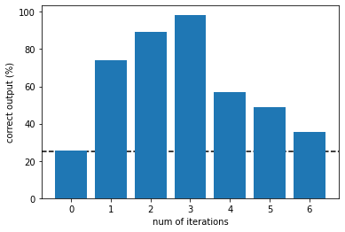

```python
import matplotlib.pyplot as plt
%matplotlib inline

backend = Aer.get_backend('qasm_simulator')
niter = tuple(range(7))
num_correct = []
shots = 10000

for i in niter:
    qc = week2b_ans_alt3(lightsout4_2x2, 2, 2, niter=[1,i])
    job = execute(qc, backend, shots=shots)
    answer = job.result().get_counts()['01']
    num_correct.append(answer / shots * 100)

plt.bar(niter, num_correct, width=0.8)
plt.axhline(y=25, linestyle="--", color='k', zorder=-1)
plt.xticks(niter)
plt.xlabel('num of iterations')
plt.ylabel('correct output (%)')
plt.show()
```

### 4th Attempt: Sequential Grover's Algorithm [Submitted]

However, we can also decouple the 2 grover iteration, doing them sequentially instead, as shown below.  
This saves having to reverse the one of the Grover sequences when moving onto another iteration.  
Thus, this method has a lower cost per iteration, and still seems to solve the given problem.

```
OrderedDict([('u', 670), ('cx', 581), ('measure', 2)])
```

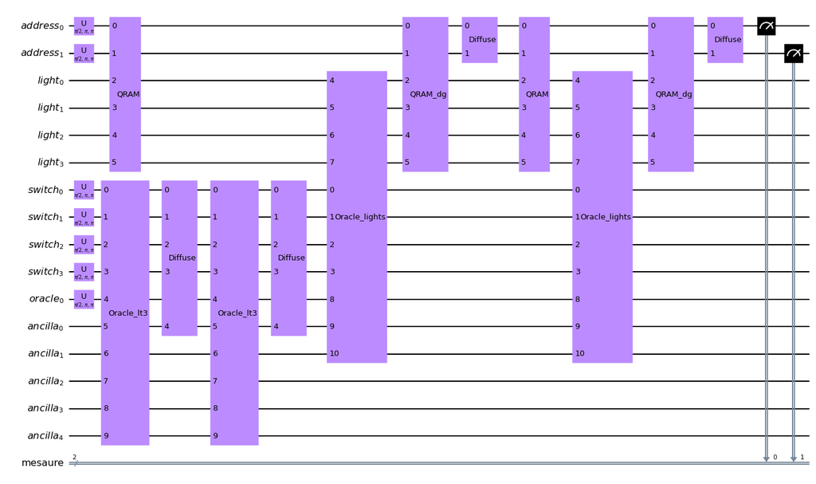

```python
def week2b_ans_func(data, nrows=3, ncols=3, niter=[1,1], grading=True):
    """ Grover search algorithm to find which lights-out puzzle
    can be solved by less than 3 switch flips

    Parameters:
        data (2D list): list of lights-out puzzles (up to 4); each puzzle
                        has a list indicating which lights are on/off
        nrows (int): number of rows in lights-out board
        ncols (int): number of columns in lights-out board
        niter (list of int): number of iterations for [0] 1st Grover for
                             switches w/ <= 3 flips, and [1] 2nd Grover for
                             address solvable by those switches
        grading (bool): True to reverse-bits & unroll for grading

    Returns:
        QuantumCircuit for 2 address qubits, (nrows * ncols) lights register,
        (nrows * ncols) switches register, max(nbits-1, 2*nadder-1, nadder + 2)
        auxiliary |0> qubits, and (nrows * ncols) classical measurement register
    """
    # declare variables
    nbits = nrows * ncols
    nadder = len(bin(nbits))-2
    assert(len(data[0]) == nbits and len(data) <= 4)

    # declare subcircuits
    qrm = qram4(data, reverse=True).to_instruction()
    add = adder(nbits).to_instruction()
    ora_lo = oracle_lightsout(nrows, ncols, off_val=1, ancillae_init=True).to_instruction()
    ora_add = oracle_lt3(nbits, ancillae_init=True)
    diff_sw = diffuse(nbits, start="-").to_instruction()
    diff_addr = diffuse(2, start="-").to_instruction()

    # declare quantum circit
    addresses = QuantumRegister(2, 'address') # address of boards
    lights = QuantumRegister(nbits, 'light') # lights-out boards
    switches = QuantumRegister(nbits, 'switch') # to switch lights
    oracle = QuantumRegister(1, 'oracle') # oracle phase flip ancilla
    ancillae = QuantumRegister(max(nbits-2, 2*nadder-1), 'ancilla')
    measure = ClassicalRegister(2, 'mesaure') # to measure address into
    ex2b = QuantumCircuit(addresses, lights, switches, oracle, ancillae, measure)

    # initilaise qubits
    ex2b.u(pi/2, pi, pi, addresses) # |->, start='-' in diffuse
    ex2b.u(pi/2, pi, pi, switches)
    ex2b.u(pi/2, pi, pi, oracle) # for oracle phase flips

    # Grover to find switches w/ <= 3 flips
    for _ in range(niter[0]):
        ex2b.append(ora_add, [*switches, oracle, *ancillae[:2*nadder-1]])
        ex2b.append(diff_sw, [*switches, *ancillae[:nbits-3]])

    # Grover to find addresses solvable by the above switches
    for _ in range(niter[1]):
        ex2b.append(qrm, [*addresses, *lights])
        ex2b.append(ora_lo, [*switches, *lights, oracle, *ancillae[:nbits-2]])
        ex2b.append(qrm.inverse(), [*addresses, *lights])
        ex2b.append(diff_addr, addresses)

    # output
    ex2b.measure(addresses, measure)
    if grading: # optimisation
        ex2b = ex2b.reverse_bits()
        ex2b = PassManager(Unroller(['u', 'cx'])).run(ex2b)
        ex2b = PassManager(Optimize1qGatesDecomposition(['u', 'cx'])).run(ex2b)

    return ex2b

# calculate score contribution
qc = week2b_ans_func(lightsout4, 3, 3, niter=[1,1], grading=True)
print(pass_manager.run(qc).count_ops())

# draw circuit
qc = week2b_ans_func(lightsout4_2x2, 2, 2, niter=[2,2], grading=False)
qc.draw(output="mpl", fold=50)
```

The number of iterations of the 2 Grover algorithm has to be optimised independently.  
However, the circuit to solve the 3x3 boards is quite large and takes too long to simulate.  
Thus, I'm not optimising it here, and instead just demonstrate that it behaves as expected for a simpler variant.

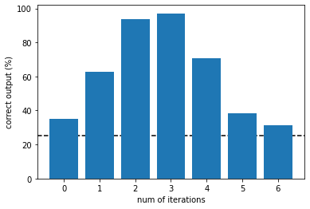

```python
import matplotlib.pyplot as plt
%matplotlib inline

backend = Aer.get_backend('qasm_simulator')
niter = tuple(range(7))
num_correct = []
shots = 10000

for i in niter:
    qc = week2b_ans_func(lightsout4_2x2, 2, 2, niter=[i,1])
    job = execute(qc, backend, shots=shots)
    answer = job.result().get_counts()['01']
    num_correct.append(answer / shots * 100)

plt.bar(niter, num_correct, width=0.8)
plt.axhline(y=25, linestyle="--", color='k', zorder=-1)
plt.xticks(niter)
plt.xlabel('num of iterations')
plt.ylabel('correct output (%)')
plt.show()
```

Below, I submit the lower cost it with the minimum of 1 iteration of each Grover search.

```python
# Submission code
from qc_grader import prepare_ex2b, grade_ex2b, submit_ex2b

# Execute your circuit with following prepare_ex2b() function.
# The prepare_ex2b() function works like the execute() function with only QuantumCircuit as an argument.
job  =  prepare_ex2b(week2b_ans_func)
counts = job.result().get_counts()[0]

# The bit string with the highest number of observations is treated as the solution
counts_desc = sorted(counts.items(), key = lambda x: x[1], reverse=True)
print(counts_desc[:5])
```

```
Running week2b_ans_func...
Computing cost...
Starting experiments. Please wait...
You may monitor the job (id: 5fc222d3758a9f0019c411c6) status and proceed to grading when it successfully completes.
[('01', 2030), ('10', 2022), ('00', 1992), ('11', 1956)]
```

```python
# Check your answer by executing following code.
# The quantum cost of the QuantumCircuit is obtained as the score. The quantum cost is related to rank only in the third week.
grade_ex2b(job)
```

```
Grading your answer. Please wait...

Congratulations 🎉! Your answer is correct.
Your score is 6480.
Feel free to submit your answer.
```

```python
# Submit your results by executing following code. You can submit as many times as you like during the period.
submit_ex2b(job)
```

```
Submitting your answer. Please wait...

Success 🎉! Your answer has been submitted.
There seems to be huge "noise clusters" interfering with Dr. Ryoko’s device. Can you please help?
```